# R Notebook

```r
df <- read.csv("car.csv")
df <- data.frame(lapply(df, factor))
head(df)
```

|  | buying | maint | doors | persons | lug_boot | safety | acceptability |
| --- | --- | --- | --- | --- | --- | --- | --- |
| 1 | vhigh | low | 5more | 4 | small | low | unacc |
| 2 | high | vhigh | 3 | 2 | med | low | unacc |
| 3 | vhigh | high | 4 | 4 | big | med | unacc |
| 4 | high | vhigh | 5more | 4 | med | low | unacc |
| 5 | vhigh | high | 5more | 2 | med | high | unacc |
| 6 | med | vhigh | 4 | more | small | med | unacc |

```r
str(df)
```

```
'data.frame':   1000 obs. of  7 variables:
 $ buying       : Factor w/ 4 levels "high","low","med",..: 4 1 4 1 4 3 3 2 3 3 ...
 $ maint        : Factor w/ 4 levels "high","low","med",..: 2 4 1 4 1 4 3 4 2 2 ...
 $ doors        : Factor w/ 4 levels "2","3","4","5more": 4 2 3 4 4 3 3 1 3 3 ...
 $ persons      : Factor w/ 3 levels "2","4","more": 2 1 2 2 1 3 1 3 2 3 ...
 $ lug_boot     : Factor w/ 3 levels "big","med","small": 3 2 1 2 2 3 1 1 3 1 ...
 $ safety       : Factor w/ 3 levels "high","low","med": 2 2 3 2 1 3 3 1 3 3 ...
 $ acceptability: Factor w/ 4 levels "acc","good","unacc",..: 3 3 3 3 3 3 3 1 1 2 ...
```

```r
table(df$acceptability)
```

```
  acc  good unacc vgood
  231    41   693    35
```

```r
table(df$buying, df$acceptability)
```

```
        acc good unacc vgood
  high   72    0   198     0
  low    51   27   138    22
  med    68   14   162    13
  vhigh  40    0   195     0
```

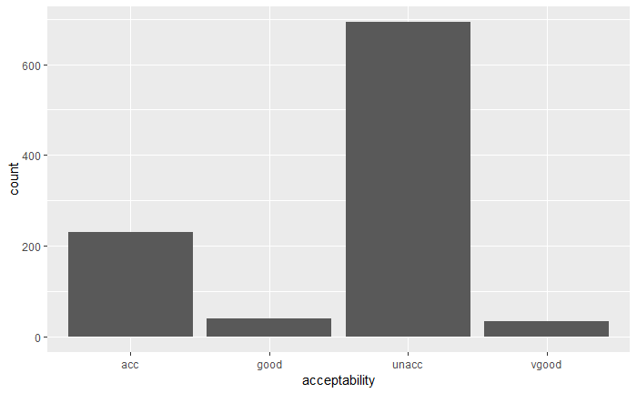

```r
library(ggplot2)
ggplot(df, aes(x = acceptability)) + geom_bar()
```

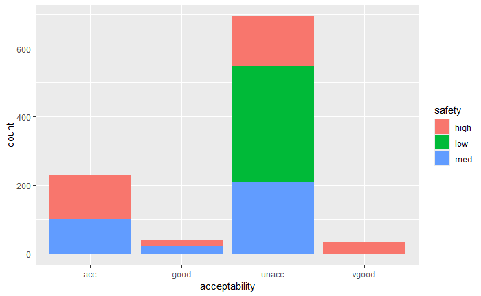

```r
ggplot(df, aes(x = acceptability, fill = safety)) + geom_bar()
```

The bar chart shows that all “vgood” rated cars have high safety, suggesting high safety is required (but not sufficient) for a car to be rated very good.

```r
#install.packages("infotheo")
```

```r
library(infotheo)
m <- mutinformation(df)
m
```

```
                   buying       maint        doors
buying        1.384665780 0.002630072 0.0026151109
maint         0.002630072 1.385994865 0.0024207885
doors         0.002615111 0.002420789 1.3859951924
persons       0.001730250 0.001993803 0.0011250103
lug_boot      0.001278166 0.000608941 0.0015724629
safety        0.001601456 0.001308771 0.0003522822
acceptability 0.067509707 0.059097457 0.0039909755
                  persons     lug_boot       safety
buying        0.001730250 0.0012781665 0.0016014559
maint         0.001993803 0.0006089410 0.0013087713
doors         0.001125010 0.0015724629 0.0003522822
persons       1.098231785 0.0014514422 0.0017740655
lug_boot      0.001451442 1.0983887270 0.0001767061
safety        0.001774065 0.0001767061 1.0985753063
acceptability 0.149276771 0.0173662202 0.1915381199
              acceptability
buying          0.067509707
maint           0.059097457
doors           0.003990976
persons         0.149276771
lug_boot        0.017366220
safety          0.191538120
acceptability   0.840929362
```

Safety and persons show the strongest mutual information with acceptability, while doors shows almost none.

```r
chisq.test(df$buying, df$acceptability)
```

```
    Pearson's Chi-squared test

data:  df$buying and df$acceptability
X-squared = 113.82, df = 9, p-value < 2.2e-16
```

```r
chisq.test(df$buying, df$maint)
```

```
    Pearson's Chi-squared test

data:  df$buying and df$maint
X-squared = 5.3384, df = 9, p-value = 0.8039
```

Buying price is significantly associated with acceptability (p < 0.001), but not with maintenance cost (p = 0.80), showing the test correctly distinguishes related and unrelated variable pairs.

```r
#install.packages("caTools")
library(caTools)
set.seed(123)
split = sample.split(df$acceptability, SplitRatio = 0.8)
df_train = subset(df, split == TRUE)
df_test = subset(df, split == FALSE)
```

```r
#install.packages("C50")
#install.packages("caret")
library(C50)
library(caret)
```

```r
dt_model <- C5.0(df_train[-7], df_train$acceptability)
```

```r
dt_pred <- predict(dt_model, df_test)
```

```r
confusionMatrix(dt_pred, df_test$acceptability)
```

```
Confusion Matrix and Statistics

          Reference
Prediction acc good unacc vgood
     acc    43    1     3     0
     good    2    7     0     0
     unacc   1    0   136     0
     vgood   0    0     0     7

Overall Statistics

               Accuracy : 0.965
                 95% CI : (0.9292, 0.9858)
    No Information Rate : 0.695
    P-Value [Acc > NIR] : < 2.2e-16

                  Kappa : 0.925

 Mcnemar's Test P-Value : NA

Statistics by Class:

                     Class: acc Class: good
Sensitivity              0.9348      0.8750
Specificity              0.9740      0.9896
Pos Pred Value           0.9149      0.7778
Neg Pred Value           0.9804      0.9948
Prevalence               0.2300      0.0400
Detection Rate           0.2150      0.0350
Detection Prevalence     0.2350      0.0450
Balanced Accuracy        0.9544      0.9323
                     Class: unacc Class: vgood
Sensitivity                0.9784        1.000
Specificity                0.9836        1.000
Pos Pred Value             0.9927        1.000
Neg Pred Value             0.9524        1.000
Prevalence                 0.6950        0.035
Detection Rate             0.6800        0.035
Detection Prevalence       0.6850        0.035
Balanced Accuracy          0.9810        1.000
```

```r
#install.packages("e1071")
library(e1071)
```

```r
set.seed(123)
nb_model = naiveBayes(df_train[,-7], df_train$acceptability)
```

```r
nb_pred = predict(nb_model, df_test)
confusionMatrix(nb_pred, df_test$acceptability)
```

```
Confusion Matrix and Statistics

          Reference
Prediction acc good unacc vgood
     acc    33    2     9     4
     good    1    5     0     1
     unacc  12    1   130     0
     vgood   0    0     0     2

Overall Statistics

               Accuracy : 0.85
                 95% CI : (0.7928, 0.8965)
    No Information Rate : 0.695
    P-Value [Acc > NIR] : 3.117e-07

                  Kappa : 0.6638

 Mcnemar's Test P-Value : NA

Statistics by Class:

                     Class: acc Class: good
Sensitivity              0.7174      0.6250
Specificity              0.9026      0.9896
Pos Pred Value           0.6875      0.7143
Neg Pred Value           0.9145      0.9845
Prevalence               0.2300      0.0400
Detection Rate           0.1650      0.0250
Detection Prevalence     0.2400      0.0350
Balanced Accuracy        0.8100      0.8073
                     Class: unacc Class: vgood
Sensitivity                0.9353       0.2857
Specificity                0.7869       1.0000
Pos Pred Value             0.9091       1.0000
Neg Pred Value             0.8421       0.9747
Prevalence                 0.6950       0.0350
Detection Rate             0.6500       0.0100
Detection Prevalence       0.7150       0.0100
Balanced Accuracy          0.8611       0.6429
```

Naive Bayes achieved 85% accuracy, notably lower than the decision tree’s 96.5%. This may be because naive Bayes assumes feature independence, while acceptability appears to depend on combinations of features (e.g. safety and persons together).

```r
library(nnet)
```

```r
lg_model <- multinom(acceptability ~ ., data = df_train)
```

```r
lg_pred <- predict(lg_model, df_test)
```

```r
confusionMatrix(lg_pred, df_test$acceptability)
```

```
Confusion Matrix and Statistics

          Reference
Prediction acc good unacc vgood
     acc    44    2     8     0
     good    1    6     0     1
     unacc   1    0   131     0
     vgood   0    0     0     6

Overall Statistics

               Accuracy : 0.935
                 95% CI : (0.8914, 0.9649)
    No Information Rate : 0.695
    P-Value [Acc > NIR] : < 2.2e-16

                  Kappa : 0.8636

 Mcnemar's Test P-Value : NA

Statistics by Class:

                     Class: acc Class: good
Sensitivity              0.9565      0.7500
Specificity              0.9351      0.9896
Pos Pred Value           0.8148      0.7500
Neg Pred Value           0.9863      0.9896
Prevalence               0.2300      0.0400
Detection Rate           0.2200      0.0300
Detection Prevalence     0.2700      0.0400
Balanced Accuracy        0.9458      0.8698
                     Class: unacc Class: vgood
Sensitivity                0.9424       0.8571
Specificity                0.9836       1.0000
Pos Pred Value             0.9924       1.0000
Neg Pred Value             0.8824       0.9948
Prevalence                 0.6950       0.0350
Detection Rate             0.6550       0.0300
Detection Prevalence       0.6600       0.0300
Balanced Accuracy          0.9630       0.9286
```

Multinomial logistic regression achieved 93.5% accuracy, second-best so far behind the decision tree.

```r
library(e1071)
svm_model <- svm(acceptability ~ ., data = df_train)
svm_pred <- predict(svm_model, df_test)
confusionMatrix(svm_pred, df_test$acceptability)
```

```
Confusion Matrix and Statistics

          Reference
Prediction acc good unacc vgood
     acc    46    8     9     7
     good    0    0     0     0
     unacc   0    0   130     0
     vgood   0    0     0     0

Overall Statistics

               Accuracy : 0.88
                 95% CI : (0.8267, 0.9216)
    No Information Rate : 0.695
    P-Value [Acc > NIR] : 5.983e-10

                  Kappa : 0.7435

 Mcnemar's Test P-Value : NA

Statistics by Class:

                     Class: acc Class: good
Sensitivity              1.0000        0.00
Specificity              0.8442        1.00
Pos Pred Value           0.6571         NaN
Neg Pred Value           1.0000        0.96
Prevalence               0.2300        0.04
Detection Rate           0.2300        0.00
Detection Prevalence     0.3500        0.00
Balanced Accuracy        0.9221        0.50
                     Class: unacc Class: vgood
Sensitivity                0.9353        0.000
Specificity                1.0000        1.000
Pos Pred Value             1.0000          NaN
Neg Pred Value             0.8714        0.965
Prevalence                 0.6950        0.035
Detection Rate             0.6500        0.000
Detection Prevalence       0.6500        0.000
Balanced Accuracy          0.9676        0.500
```

SVM achieved 88% accuracy but completely failed to predict “good” or “vgood” classes, always defaulting to “acc” or “unacc” — likely due to class imbalance in the training data.

```r
nn_model <- nnet(acceptability ~ ., data = df_train, size = 5)
nn_pred <- predict(nn_model, df_test, type = "class")
confusionMatrix(factor(nn_pred), df_test$acceptability)
```

```
Confusion Matrix and Statistics

          Reference
Prediction acc good unacc vgood
     acc    39    2     3     0
     good    2    4     0     2
     unacc   5    0   136     0
     vgood   0    2     0     5

Overall Statistics

               Accuracy : 0.92
                 95% CI : (0.8733, 0.9536)
    No Information Rate : 0.695
    P-Value [Acc > NIR] : 9.906e-15

                  Kappa : 0.8248

 Mcnemar's Test P-Value : NA

Statistics by Class:

                     Class: acc Class: good
Sensitivity              0.8478      0.5000
Specificity              0.9675      0.9792
Pos Pred Value           0.8864      0.5000
Neg Pred Value           0.9551      0.9792
Prevalence               0.2300      0.0400
Detection Rate           0.1950      0.0200
Detection Prevalence     0.2200      0.0400
Balanced Accuracy        0.9077      0.7396
                     Class: unacc Class: vgood
Sensitivity                0.9784       0.7143
Specificity                0.9180       0.9896
Pos Pred Value             0.9645       0.7143
Neg Pred Value             0.9492       0.9896
Prevalence                 0.6950       0.0350
Detection Rate             0.6800       0.0250
Detection Prevalence       0.7050       0.0350
Balanced Accuracy          0.9482       0.8520
```

Neural network achieved ~92% accuracy, performing reasonably well across all classes, though slightly below the decision tree.

```r
library(caret)
ctrl <- trainControl(method = 'cv', number = 10)
set.seed(123)
dt_cv_model <- train(df_train[,-7], df_train[,7], 'C5.0', trControl = ctrl)
dt_cv_model
```

```
C5.0

800 samples
  6 predictor
  4 classes: 'acc', 'good', 'unacc', 'vgood'

No pre-processing
Resampling: Cross-Validated (10 fold)
Summary of sample sizes: 720, 720, 720, 719, 719, 721, ...
Resampling results across tuning parameters:

  model  winnow  trials  Accuracy   Kappa
  rules  FALSE    1      0.9437152  0.8788563
  rules  FALSE   10      0.9649193  0.9238347
  rules  FALSE   20      0.9686539  0.9320985
  rules   TRUE    1      0.9412307  0.8739225
  rules   TRUE   10      0.9525273  0.8985032
  rules   TRUE   20      0.9587465  0.9118012
  tree   FALSE    1      0.9399648  0.8712915
  tree   FALSE   10      0.9574344  0.9081932
  tree   FALSE   20      0.9587160  0.9122389
  tree    TRUE    1      0.9387148  0.8689473
  tree    TRUE   10      0.9450115  0.8825120
  tree    TRUE   20      0.9463086  0.8860704

Accuracy was used to select the optimal model
 using the largest value.
The final values used for the model were trials
 = 20, model = rules and winnow = FALSE.
```

```r
dt_cv_pred <- predict(dt_cv_model, df_test)
confusionMatrix(dt_cv_pred, df_test$acceptability)
```

```
Confusion Matrix and Statistics

          Reference
Prediction acc good unacc vgood
     acc    45    1     0     0
     good    1    7     0     0
     unacc   0    0   139     0
     vgood   0    0     0     7

Overall Statistics

               Accuracy : 0.99
                 95% CI : (0.9643, 0.9988)
    No Information Rate : 0.695
    P-Value [Acc > NIR] : < 2.2e-16

                  Kappa : 0.9783

 Mcnemar's Test P-Value : NA

Statistics by Class:

                     Class: acc Class: good
Sensitivity              0.9783      0.8750
Specificity              0.9935      0.9948
Pos Pred Value           0.9783      0.8750
Neg Pred Value           0.9935      0.9948
Prevalence               0.2300      0.0400
Detection Rate           0.2250      0.0350
Detection Prevalence     0.2300      0.0400
Balanced Accuracy        0.9859      0.9349
                     Class: unacc Class: vgood
Sensitivity                 1.000        1.000
Specificity                 1.000        1.000
Pos Pred Value              1.000        1.000
Neg Pred Value              1.000        1.000
Prevalence                  0.695        0.035
Detection Rate              0.695        0.035
Detection Prevalence        0.695        0.035
Balanced Accuracy           1.000        1.000
```

Applying 10-fold cross-validation with caret improved the decision tree’s accuracy from 96.5% to 99%, correctly classifying every “unacc” and “vgood” case in the test set.

```r
ctrl <- trainControl(method = 'cv', number = 10)
set.seed(123)
nb_cv_model <- train(df_train[,-7], df_train[,7], 'nb', trControl = ctrl)
```

```
1 package is needed and is not installed. (klaR). Would you like to try to install it now?
1: yes
2: no
```

```r
1
nb_cv_model
```

```
Naive Bayes

800 samples
  6 predictor
  4 classes: 'acc', 'good', 'unacc', 'vgood'

No pre-processing
Resampling: Cross-Validated (10 fold)
Summary of sample sizes: 720, 720, 720, 719, 719, 721, ...
Resampling results across tuning parameters:

  usekernel  Accuracy   Kappa
  FALSE      0.8362418  0.6274638
   TRUE      0.8362418  0.6274638

Tuning parameter 'fL' was held constant at a
 value of 0
Tuning parameter 'adjust' was
 held constant at a value of 1
Accuracy was used to select the optimal model
 using the largest value.
The final values used for the model were fL =
 0, usekernel = FALSE and adjust = 1.
```

```r
nb_cv_pred <- predict(nb_cv_model, df_test)
confusionMatrix(nb_cv_pred, df_test$acceptability)
```

```
Confusion Matrix and Statistics

          Reference
Prediction acc good unacc vgood
     acc    33    2     9     4
     good    1    5     0     1
     unacc  12    1   130     0
     vgood   0    0     0     2

Overall Statistics

               Accuracy : 0.85
                 95% CI : (0.7928, 0.8965)
    No Information Rate : 0.695
    P-Value [Acc > NIR] : 3.117e-07

                  Kappa : 0.6638

 Mcnemar's Test P-Value : NA

Statistics by Class:

                     Class: acc Class: good
Sensitivity              0.7174      0.6250
Specificity              0.9026      0.9896
Pos Pred Value           0.6875      0.7143
Neg Pred Value           0.9145      0.9845
Prevalence               0.2300      0.0400
Detection Rate           0.1650      0.0250
Detection Prevalence     0.2400      0.0350
Balanced Accuracy        0.8100      0.8073
                     Class: unacc Class: vgood
Sensitivity                0.9353       0.2857
Specificity                0.7869       1.0000
Pos Pred Value             0.9091       1.0000
Neg Pred Value             0.8421       0.9747
Prevalence                 0.6950       0.0350
Detection Rate             0.6500       0.0100
Detection Prevalence       0.7150       0.0100
Balanced Accuracy          0.8611       0.6429
```

Cross-validation did not improve naive Bayes (still 85% accuracy) — unlike the decision tree, which improved from 96.5% to 99%. This suggests naive Bayes’ independence assumption is a fundamental limitation on this dataset, not something tuning can fix.

```r
ctrl <- trainControl(method = 'cv', number = 10)
set.seed(123)
lg_cv_model <- train(df_train[,-7], df_train[,7], 'multinom', trControl = ctrl, trace = FALSE)
lg_cv_model
```

```
Penalized Multinomial Regression

800 samples
  6 predictor
  4 classes: 'acc', 'good', 'unacc', 'vgood'

No pre-processing
Resampling: Cross-Validated (10 fold)
Summary of sample sizes: 720, 720, 720, 719, 719, 721, ...
Resampling results across tuning parameters:

  decay  Accuracy   Kappa
  0e+00  0.9250107  0.8399003
  1e-04  0.9237287  0.8367283
  1e-01  0.8988533  0.7820909

Accuracy was used to select the optimal model using the largest value.
The final value used for the model was decay = 0.
```

```r
lg_cv_pred <- predict(lg_cv_model, df_test)
confusionMatrix(lg_cv_pred, df_test$acceptability)
```

```
Confusion Matrix and Statistics

          Reference
Prediction acc good unacc vgood
     acc    44    2     8     0
     good    1    6     0     1
     unacc   1    0   131     0
     vgood   0    0     0     6

Overall Statistics

               Accuracy : 0.935
                 95% CI : (0.8914, 0.9649)
    No Information Rate : 0.695
    P-Value [Acc > NIR] : < 2.2e-16

                  Kappa : 0.8636

 Mcnemar's Test P-Value : NA

Statistics by Class:

                     Class: acc Class: good Class: unacc Class: vgood
Sensitivity              0.9565      0.7500       0.9424       0.8571
Specificity              0.9351      0.9896       0.9836       1.0000
Pos Pred Value           0.8148      0.7500       0.9924       1.0000
Neg Pred Value           0.9863      0.9896       0.8824       0.9948
Prevalence               0.2300      0.0400       0.6950       0.0350
Detection Rate           0.2200      0.0300       0.6550       0.0300
Detection Prevalence     0.2700      0.0400       0.6600       0.0300
Balanced Accuracy        0.9458      0.8698       0.9630       0.9286
```

Cross-validation confirmed decay=0 as optimal, matching the basic model’s default — accuracy stayed at 93.5%, unchanged from the non-CV version.

```r
set.seed(123)
install.packages("kernlab")
library(kernlab)
svm_cv_model <- ksvm(acceptability ~ ., data = df_train, kernel = "vanilladot", cross = 10)
svm_cv_model
```

```
Support Vector Machine object of class "ksvm"

SV type: C-svc  (classification)
 parameter : cost C = 1

Linear (vanilla) kernel function.

Number of Support Vectors : 290

Objective Function Value : -40.9483 -137.875 -17.3171 -20 -14 -11.7143
Training error : 0.07375
Cross validation error : 0.09625
```

```r
svm_cv_pred <- predict(svm_cv_model, df_test)
confusionMatrix(svm_cv_pred, df_test$acceptability)
```

```
Confusion Matrix and Statistics

          Reference
Prediction acc good unacc vgood
     acc    43    2     6     0
     good    0    6     0     0
     unacc   3    0   133     0
     vgood   0    0     0     7

Overall Statistics

               Accuracy : 0.945
                 95% CI : (0.9037, 0.9722)
    No Information Rate : 0.695
    P-Value [Acc > NIR] : < 2.2e-16

                  Kappa : 0.8821

 Mcnemar's Test P-Value : NA

Statistics by Class:

                     Class: acc Class: good Class: unacc Class: vgood
Sensitivity              0.9348      0.7500       0.9568        1.000
Specificity              0.9481      1.0000       0.9508        1.000
Pos Pred Value           0.8431      1.0000       0.9779        1.000
Neg Pred Value           0.9799      0.9897       0.9063        1.000
Prevalence               0.2300      0.0400       0.6950        0.035
Detection Rate           0.2150      0.0300       0.6650        0.035
Detection Prevalence     0.2550      0.0300       0.6800        0.035
Balanced Accuracy        0.9414      0.8750       0.9538        1.000
```

SVM improved dramatically with cross-validation (88% → 94.5%), and critically, it stopped ignoring the rare “good”/“vgood” classes entirely — correctly identifying 6/8 good and 7/7 vgood cars, compared to 0 in the basic version.

```r
ctrl <- trainControl(method = 'cv', number = 10)
set.seed(123)
nn_cv_model <- train(df_train[,-7], df_train[,7], 'nnet', trControl = ctrl, trace = FALSE)
nn_cv_model
```

```
Neural Network

800 samples
  6 predictor
  4 classes: 'acc', 'good', 'unacc', 'vgood'

No pre-processing
Resampling: Cross-Validated (10 fold)
Summary of sample sizes: 720, 720, 720, 719, 719, 721, ...
Resampling results across tuning parameters:

  size  decay  Accuracy   Kappa
  1     0e+00  0.8924644  0.7455647
  1     1e-04  0.8928352  0.7773275
  1     1e-01  0.8837584  0.7411449
  3     0e+00  0.9413094  0.8759124
  3     1e-04  0.9375428  0.8654737
  3     1e-01  0.9425119  0.8763303
  5     0e+00  0.9337137  0.8582732
  5     1e-04  0.9412303  0.8712777
  5     1e-01  0.9587322  0.9114996

Accuracy was used to select the optimal model using the largest value.
The final values used for the model were size = 5 and decay = 0.1.
```

```r
nn_cv_pred <- predict(nn_cv_model, df_test)
confusionMatrix(nn_cv_pred, df_test$acceptability)
```

```
Confusion Matrix and Statistics

          Reference
Prediction acc good unacc vgood
     acc    44    1     1     0
     good    0    7     0     1
     unacc   1    0   138     0
     vgood   1    0     0     6

Overall Statistics

               Accuracy : 0.975
                 95% CI : (0.9426, 0.9918)
    No Information Rate : 0.695
    P-Value [Acc > NIR] : < 2.2e-16

                  Kappa : 0.9458

 Mcnemar's Test P-Value : NA

Statistics by Class:

                     Class: acc Class: good Class: unacc Class: vgood
Sensitivity              0.9565      0.8750       0.9928       0.8571
Specificity              0.9870      0.9948       0.9836       0.9948
Pos Pred Value           0.9565      0.8750       0.9928       0.8571
Neg Pred Value           0.9870      0.9948       0.9836       0.9948
Prevalence               0.2300      0.0400       0.6950       0.0350
Detection Rate           0.2200      0.0350       0.6900       0.0300
Detection Prevalence     0.2300      0.0400       0.6950       0.0350
Balanced Accuracy        0.9718      0.9349       0.9882       0.9260
```

Neural network improved from ~92% to 97.5% with cross-validation, which found size=5, decay=0.1 as optimal — showing that a moderate overfitting penalty (decay) combined with sufficient complexity (size) outperforms either alone.

```r
colnames(df_train)
```

```
[1] "buying"        "maint"         "doors"         "persons"       "lug_boot"
[6] "safety"        "acceptability"
```

```r
dt_fs_model <- C5.0(df_train[, c("safety","persons","buying")], df_train$acceptability)
dt_fs_pred <- predict(dt_fs_model, df_test)
confusionMatrix(dt_fs_pred, df_test$acceptability)
```

```
Confusion Matrix and Statistics

          Reference
Prediction acc good unacc vgood
     acc    40    8    15     7
     good    0    0     0     0
     unacc   6    0   124     0
     vgood   0    0     0     0

Overall Statistics

               Accuracy : 0.82
                 95% CI : (0.7596, 0.8706)
    No Information Rate : 0.695
    P-Value [Acc > NIR] : 4.13e-05

                  Kappa : 0.6152

 Mcnemar's Test P-Value : NA

Statistics by Class:

                     Class: acc Class: good Class: unacc Class: vgood
Sensitivity              0.8696        0.00       0.8921        0.000
Specificity              0.8052        1.00       0.9016        1.000
Pos Pred Value           0.5714         NaN       0.9538          NaN
Neg Pred Value           0.9538        0.96       0.7857        0.965
Prevalence               0.2300        0.04       0.6950        0.035
Detection Rate           0.2000        0.00       0.6200        0.000
Detection Prevalence     0.3500        0.00       0.6500        0.000
Balanced Accuracy        0.8374        0.50       0.8969        0.500
```

```r
nb_fs_model <- naiveBayes(df_train[, c("safety","persons","buying")], df_train$acceptability)
nb_fs_pred <- predict(nb_fs_model, df_test)
confusionMatrix(nb_fs_pred, df_test$acceptability)
```

```
Confusion Matrix and Statistics

          Reference
Prediction acc good unacc vgood
     acc    32    5    10     7
     good    0    0     0     0
     unacc  14    3   129     0
     vgood   0    0     0     0

Overall Statistics

               Accuracy : 0.805
                 95% CI : (0.7432, 0.8575)
    No Information Rate : 0.695
    P-Value [Acc > NIR] : 0.0003038

                  Kappa : 0.5471

 Mcnemar's Test P-Value : NA

Statistics by Class:

                     Class: acc Class: good Class: unacc Class: vgood
Sensitivity              0.6957        0.00       0.9281        0.000
Specificity              0.8571        1.00       0.7213        1.000
Pos Pred Value           0.5926         NaN       0.8836          NaN
Neg Pred Value           0.9041        0.96       0.8148        0.965
Prevalence               0.2300        0.04       0.6950        0.035
Detection Rate           0.1600        0.00       0.6450        0.000
Detection Prevalence     0.2700        0.00       0.7300        0.000
Balanced Accuracy        0.7764        0.50       0.8247        0.500
```

```r
lg_fs_model <- multinom(acceptability ~ safety + persons + buying, data = df_train)
lg_fs_pred <- predict(lg_fs_model, df_test)
confusionMatrix(lg_fs_pred, df_test$acceptability)
```

```
Confusion Matrix and Statistics

          Reference
Prediction acc good unacc vgood
     acc    34    8    12     5
     good    0    0     0     0
     unacc   9    0   127     0
     vgood   3    0     0     2

Overall Statistics

               Accuracy : 0.815
                 95% CI : (0.7541, 0.8663)
    No Information Rate : 0.695
    P-Value [Acc > NIR] : 8.287e-05

                  Kappa : 0.5967

 Mcnemar's Test P-Value : NA

Statistics by Class:

                     Class: acc Class: good Class: unacc Class: vgood
Sensitivity              0.7391        0.00       0.9137       0.2857
Specificity              0.8377        1.00       0.8525       0.9845
Pos Pred Value           0.5763         NaN       0.9338       0.4000
Neg Pred Value           0.9149        0.96       0.8125       0.9744
Prevalence               0.2300        0.04       0.6950       0.0350
Detection Rate           0.1700        0.00       0.6350       0.0100
Detection Prevalence     0.2950        0.00       0.6800       0.0250
Balanced Accuracy        0.7884        0.50       0.8831       0.6351
```

```r
lg_fs_model <- multinom(acceptability ~ safety + persons + buying, data = df_train)
lg_fs_pred <- predict(lg_fs_model, df_test)
confusionMatrix(lg_fs_pred, df_test$acceptability)
```

```
Confusion Matrix and Statistics

          Reference
Prediction acc good unacc vgood
     acc    34    8    12     5
     good    0    0     0     0
     unacc   9    0   127     0
     vgood   3    0     0     2

Overall Statistics

               Accuracy : 0.815
                 95% CI : (0.7541, 0.8663)
    No Information Rate : 0.695
    P-Value [Acc > NIR] : 8.287e-05

                  Kappa : 0.5967

 Mcnemar's Test P-Value : NA

Statistics by Class:

                     Class: acc Class: good Class: unacc Class: vgood
Sensitivity              0.7391        0.00       0.9137       0.2857
Specificity              0.8377        1.00       0.8525       0.9845
Pos Pred Value           0.5763         NaN       0.9338       0.4000
Neg Pred Value           0.9149        0.96       0.8125       0.9744
Prevalence               0.2300        0.04       0.6950       0.0350
Detection Rate           0.1700        0.00       0.6350       0.0100
Detection Prevalence     0.2950        0.00       0.6800       0.0250
Balanced Accuracy        0.7884        0.50       0.8831       0.6351
```

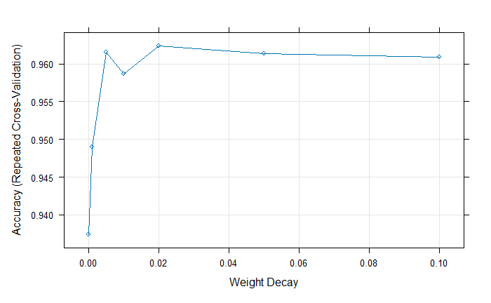

```r
ctrl <- trainControl(method = "repeatedcv", number = 10, repeats = 10)
grid <- expand.grid(size = 5, decay = c(0, 0.001, 0.005, 0.01, 0.02, 0.05, 0.1))
set.seed(123)
m <- train(df_train[,-7], df_train[,7], method = "nnet", trControl = ctrl, tuneGrid = grid, trace = FALSE)
plot(m)
```

Tuning weight decay for the neural network revealed a clear pattern: accuracy jumped sharply from ~93.8% at decay=0 to ~96% with even a small decay penalty, peaking around decay≈0.02 (~96.3%), then gradually declining as decay increased further to 0.1. This confirms a moderate regularization penalty improves generalization, while excessive penalty slightly underfits the model.

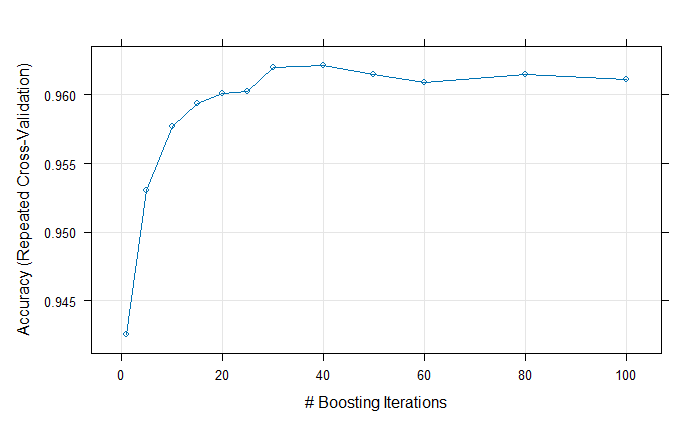

```r
ctrl <- trainControl(method = "repeatedcv", number = 10, repeats = 10)
grid <- expand.grid(model = "tree", trials = c(1,5,10,15,20,25,30,40,50,60,80,100), winnow = FALSE)
set.seed(123)
m <- train(df_train[,-7], df_train[,7], method = "C5.0", trControl = ctrl, tuneGrid = grid)
plot(m)
```

Tuning C5.0’s boosting trials showed accuracy rising sharply from ~94.3% (trials=1) to ~96% (trials≈20), peaking around trials≈30-40 (~96.2%), then plateauing with no meaningful further gain up to trials=100. This suggests trials≈30 offers the best accuracy-to- computation trade-off.